# Additional carat features

Tejus

31/10/2020

## Notes

- Make your plots only in the training set
  - Don’t use the test set for exploration!
- Things you should be looking for
  - Imbalance in outcomes/predictors
  - Outliers
  - Groups of points not explained by a predictor
  - Skewed variables

## Plotting predictors

- `iris` data set gives the measurements in centimeters of the variables sepal length and width and petal length and width, respectively, for 50 flowers from each of 3 species of iris. The species are Iris setosa, versicolor, and virginica.

```r
data("iris")
summary(iris)
```

```
##   Sepal.Length    Sepal.Width     Petal.Length    Petal.Width
##  Min.   :4.300   Min.   :2.000   Min.   :1.000   Min.   :0.100
##  1st Qu.:5.100   1st Qu.:2.800   1st Qu.:1.600   1st Qu.:0.300
##  Median :5.800   Median :3.000   Median :4.350   Median :1.300
##  Mean   :5.843   Mean   :3.057   Mean   :3.758   Mean   :1.199
##  3rd Qu.:6.400   3rd Qu.:3.300   3rd Qu.:5.100   3rd Qu.:1.800
##  Max.   :7.900   Max.   :4.400   Max.   :6.900   Max.   :2.500
##        Species
##  setosa    :50
##  versicolor:50
##  virginica :50
##
##
##
```

- **Splitting the data**

```r
Train_Index <- createDataPartition(y = iris$Species, p =0.7, list = FALSE)
train <- iris[Train_Index,]
```

### Scatterplot Matrix with *featurePlot* (*caret* package)

#### 1.) Scatterplot matrix and factor variables

- Scatterplot with pairs of data

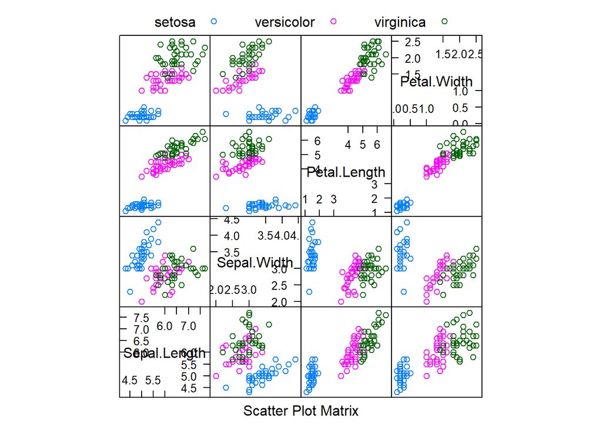

```r
featurePlot(x=train[,c("Sepal.Length", "Sepal.Width", "Petal.Length", "Petal.Width")],
            y = train$Species,
            plot="pairs",
            ## Add a key at the top
            auto.key = list(columns = 3))
```

- Scatterplot with pairs of data and ellipses

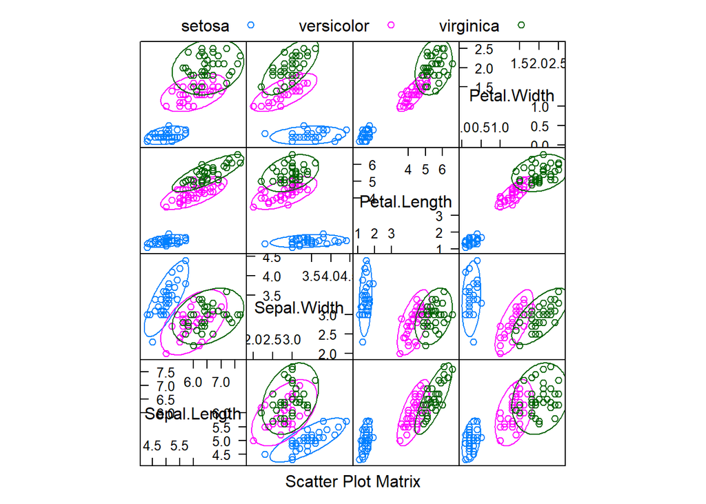

```r
featurePlot(x=train[,c("Sepal.Length", "Sepal.Width", "Petal.Length", "Petal.Width")],
            y = train$Species,
            plot="ellipse",
            ## Add a key at the top
            auto.key = list(columns = 3))
```

- Overlayed Density Plots

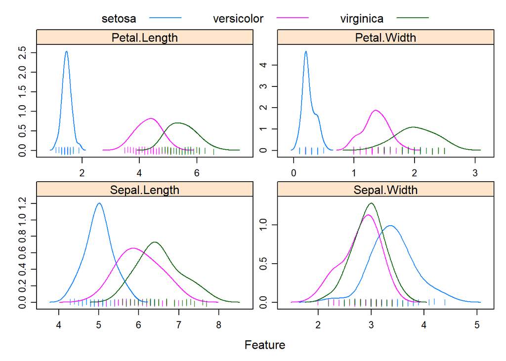

```r
featurePlot(x=train[,c("Sepal.Length", "Sepal.Width", "Petal.Length", "Petal.Width")],
            y = train$Species,
            plot="density", pch = "|",
            layout = c(2, 2), adjust = 1.5,
            scales = list(y = list(relation="free"),
                          x = list(relation="free")),
            ## Add a key at the top
            auto.key = list(columns = 3))
```

- Box Plots

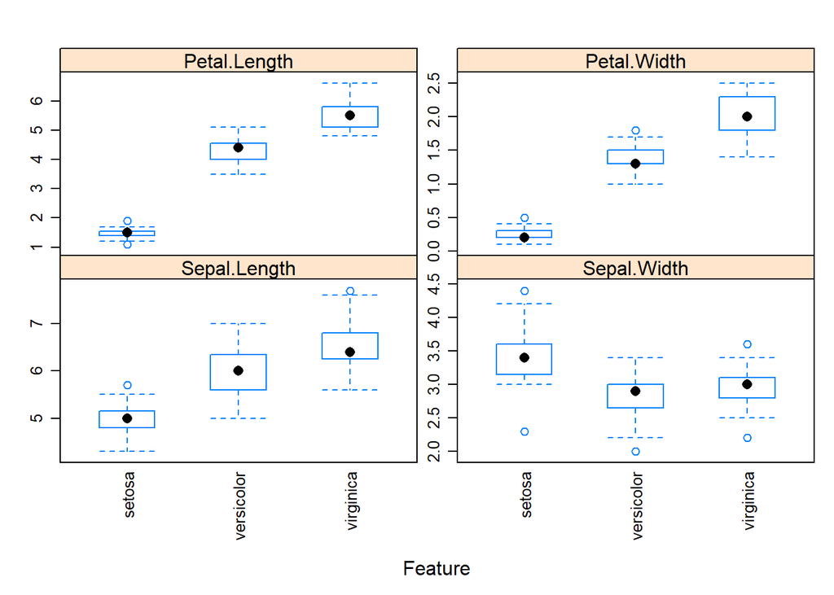

```r
featurePlot(x=train[,c("Sepal.Length", "Sepal.Width", "Petal.Length", "Petal.Width")],
            y = train$Species,
            plot="box",
            layout = c(2, 2),
            scales = list(y = list(relation="free"),
                          x = list(rot=90)),
            ## Add a key at the top
            auto.key = list(columns = 3))
```

#### 2.) Scatterplot matrix and continous variables

- For regression, the Boston Housing data is used :
- Housing data for 506 census tracts of Boston from the 1970 census. The dataframe `BostonHousing2` the corrected version with additional spatial information.
- The original data are 506 observations on 14 variables, medv (median value of owner-occupied homes in USD 1000’s) being the target variable :

```r
library(mlbench)
data(BostonHousing2)
regVar <- c("age", "lstat", "tax")
str(BostonHousing2[, regVar])
```

```
## 'data.frame':    506 obs. of  3 variables:
##  $ age  : num  65.2 78.9 61.1 45.8 54.2 58.7 66.6 96.1 100 85.9 ...
##  $ lstat: num  4.98 9.14 4.03 2.94 5.33 ...
##  $ tax  : int  296 242 242 222 222 222 311 311 311 311 ...
```

- `featurePlot` can be used to create scatter plots of each of the predictors with the outcome.

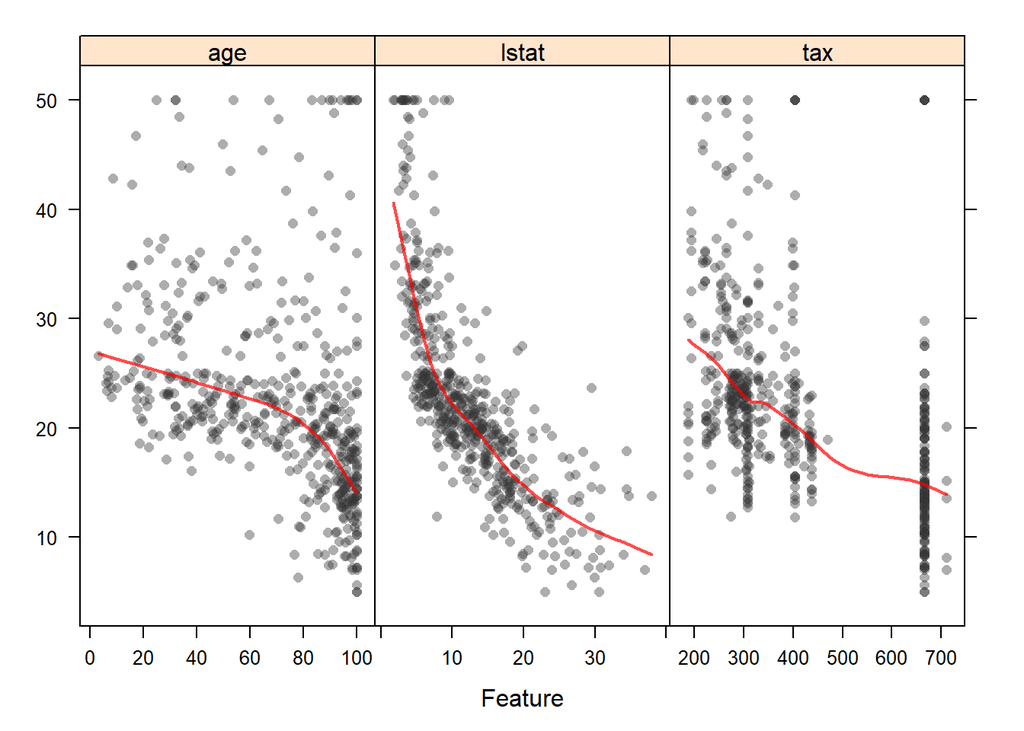

```r
theme1 <- trellis.par.get()
theme1$plot.symbol$col = rgb(.2, .2, .2, .4)
theme1$plot.symbol$pch = 16
theme1$plot.line$col = rgb(1, 0, 0, .7)
theme1$plot.line$lwd <- 2
trellis.par.set(theme1)

# actual plot
featurePlot(x = BostonHousing2[, regVar],
            y = BostonHousing2$medv,
            plot = "scatter",
            type = c("p", "smooth"),
            span = .5,
            layout = c(3, 1))
```

### Ggplot2 is always handy with smoothing

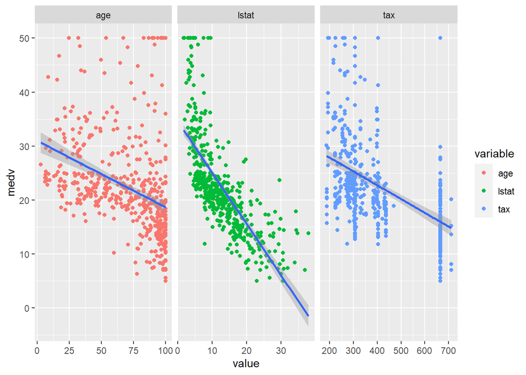

```r
Boston_Melted <- melt(BostonHousing2[,c(regVar, "medv")], measure.vars = regVar )

g <- ggplot(Boston_Melted, aes(x = value, y = medv)) + geom_point(aes(color = variable)) + facet_grid(.~variable, scales = "free_x") + geom_smooth(method='lm')
g
```

### cut2, making factors (*Hmisc* package)

- Adding factors to variables

```r
cutAge <- cut2(BostonHousing2$age,g=3)
cutLstat <- cut2(BostonHousing2$lstat,g=3)
cutTax <- cut2(BostonHousing2$tax,g=3)

ExtraFactors <- c(cutAge,  cutLstat, cutTax)

table(cutAge)
```

```
## cutAge
## [ 2.9, 56.5) [56.5, 90.3) [90.3,100.0]
##          169          169          168
```

### Ggplot for boxplot

- Boxplot with additional factors in our Regression variables

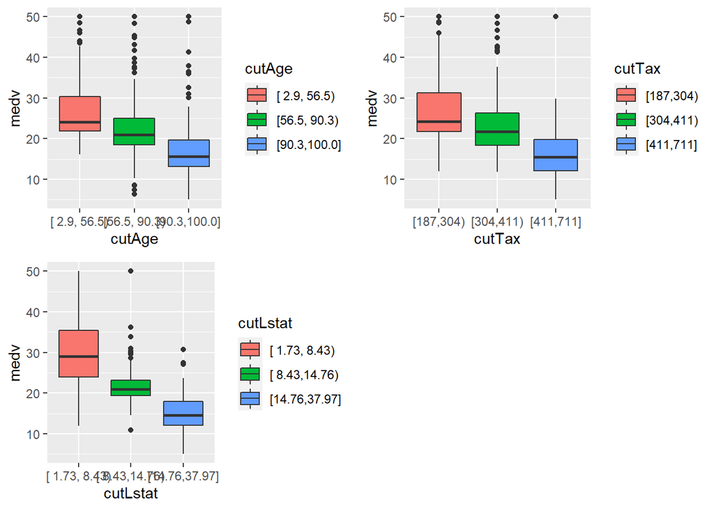

```r
g1 <- qplot(cutAge, medv, data = BostonHousing2, fill = cutAge, geom = c("boxplot"))
g2 <- qplot(cutTax, medv, data = BostonHousing2, fill = cutTax, geom = c("boxplot"))
g3 <- qplot(cutLstat, medv, data = BostonHousing2, fill = cutLstat, geom = c("boxplot"))

grid.arrange(g1, g2, g3, ncol = 2)
```